# Business Case: Scaler - Clustering

## Cluster interpretation

In this section, we will attempt to understand characteristic of various clusters discovered by KMeans algorithm using various plots and summary stats.

```python
def plot_cluster_graphs(df, labels):

    df2 = df.copy()
    df2['cluster'] = labels

    for col in ['cluster']:
        df2[col] = df2[col].astype('category')

    fig, ax = plt.subplots(3,3,figsize=(15,15))

    sns.countplot(x='cluster', data=df2, ax=ax[0][0])
    showpercent(ax[0][0], total=df2.shape[0])

    sns.boxplot(y='ctc', x='cluster', data=df2, ax=ax[0][1])
    sns.boxplot(y='experience', x='cluster', data=df2, ax=ax[0][2])

    sns.boxplot(y='designation_perc', x='cluster', data=df2, ax=ax[1][0])
    sns.boxplot(y='class_perc', x='cluster', data=df2, ax=ax[1][1])
    sns.boxplot(y='tier_perc', x='cluster', data=df2, ax=ax[1][2])

    sns.boxplot(y='company_tier_perc', x='cluster', data=df2, ax=ax[2][0])
    sns.boxplot(y='job_position_tier_perc', x='cluster', data=df2, ax=ax[2][1])

    plt.show()

def show_cluster_stats(df2, labels):

    df2['cluster'] = labels

    cluster_summary = df2.groupby('cluster').agg({
        'ctc': ['mean', 'median'],
        'experience': ['mean'],
        'designation_perc': ['mean'],
        'class_perc': ['mean'],
        'tier_perc': ['mean'],
        'company_tier_perc': ['mean'],
        'job_position_tier_perc': ['mean']
    })

    cluster_summary['ctc'] = cluster_summary['ctc']/100000
    cluster_summary = cluster_summary.rename(columns={'ctc': 'ctc(lacs)'})

    return np.round(cluster_summary.T, 2)
```

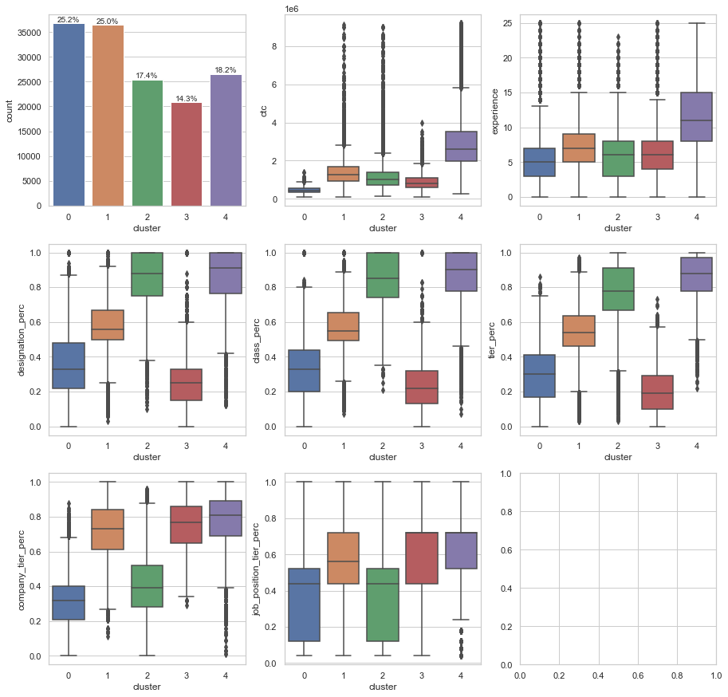

|  | cluster | 0 | 1 | 2 | 3 | 4 |
| --- | --- | --- | --- | --- | --- | --- |
| ctc(lacs) | mean | 4.51 | 14.18 | 11.71 | 8.68 | 29.43 |
|  | median | 4.30 | 12.51 | 10.00 | 8.00 | 26.00 |
| experience | mean | 5.32 | 7.24 | 5.90 | 6.16 | 11.44 |
| designation_perc | mean | 0.34 | 0.58 | 0.85 | 0.26 | 0.86 |
| class_perc | mean | 0.32 | 0.56 | 0.84 | 0.23 | 0.87 |
| tier_perc | mean | 0.29 | 0.54 | 0.77 | 0.20 | 0.86 |
| company_tier_perc | mean | 0.31 | 0.71 | 0.41 | 0.75 | 0.77 |
| job_position_tier_perc | mean | 0.37 | 0.56 | 0.40 | 0.56 | 0.69 |

```python
plot_cluster_graphs(df_final, km_5.labels_)
show_cluster_stats(df_final, km_5.labels_)
```

**Insights:**

On close examination, we can note the following characteristics for each of the five clusters identified.

[output not shown]

**Recommendations**

**1. Underpaid low performers (lower tier companies):** These learners are underpaid low performers in their current job. They are usually employed at lower tier companies, often in less lucrative roles. With appropriate up-skilling, they may potentially get a huge CTC increase either by better performance, by switching to better roles in the same company, or by switching to tier 1 companies. Scaler should pursue these learners primarily focusing on the potential for landing higher paying jobs.

**2. Underpaid low performers (high tier companies):** These learners are underpaid low performers working in tier 1 companies. After appropriate upskilling, they have potential to fetch higher paying jobs in their companies/other top tier companies. These group of learners are also likely to land higher paying jobs after upskilling, and hence Scaler should pursue them focusing on potential for landing higher ctc jobs.

**3. High potential performers (lower tier companies)** These group represents high potential learners working in low/medium tier companies. With appropriate up-skilling, they have potential to crack high paying lucrative jobs in tier 1 companies. Scaler should pursue them and focus on potential to land higher paying as well as challenging jobs in top tier companies.

**4. Average paid average performers (high tier companies):** These learners are average paid average performers working in high tier companies and lucrative job_positions. With up-skilling, they can potentially fetch higher paying jobs, better roles. These set of learners are mostly mid-tier professionals, who may also be interested in career transition.

**5. Highest paid high performers (high tier companies)**: These learners are high performing and highly paid mid/senior level employees who mostly work in top tier companies and high paying job_positions. For these group, the primary motivation could be gaining knowledge and transitioning into different roles.